Naturgeografi

# Oliens migration

Bjergarter, modelforsøg og perspektivering

**Dato:** ____________________ **Gruppe / navne:** ____________________________________________

## Om øvelsen

Øvelsen er delt i tre:

1. **Olie-geologi** — hvilke bjergarter hører til hvor i undergrunden?
2. **Det praktiske forsøg** — oliens migration op gennem sand.
3. **Oliens densitet** — måling af den forskel, der driver migrationen.

## Del 1: Olie-geologi

Ved oliens dannelse og migration er der forskellige bjergarter, der lægger sig forskellige steder i forhold til hinanden. Se på bjergartsstykkerne, de løse sedimenter og råolieprøven på bordet, og sammenhold dem med billederne herunder.

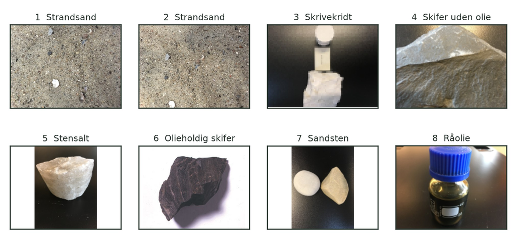

Figur 1: De otte prøver, I har på bordet. Nummeret bruges i Tabel 1.

Placér nu prøverne i skemaet, så stratigrafien passer i forhold til oliedannelse og oliefælder. Øverste række er havbunden, og så går det nedad i undergrunden. Skriv bjergartens navn og billedets nummer, og begrund hver placering.

Tabel 1: Stratigrafien fra havbunden og nedefter. Alle otte prøver skal med — to af dem kan godt høre til i samme lag.

| Lag | Bjergart + billede nr. | Begrundelse i forhold til oliedannelse og oliefælde |
| --- | --- | --- |
| Hav |  |  |
| 1 |  |  |
| 2 |  |  |
| 3 |  |  |
| 4 |  |  |
| 5 |  |  |
| 6 |  |  |

## Del 2: Praktisk øvelse — oliens migration

**Formål:** at opnå viden om oliens migration og at knytte den til densitet.

**Hypotese:** Hvad forventer I vil ske, og hvorfor? Skriv det ned, inden I går i gang.

________________________________________________________________________________________________

________________________________________________________________________________________________

### Fremgangsmåde

1. Hæld ca. 1–2 cm madolie i bunden af glasset.
2. Hæld sand oveni, indtil olien er dækket, og der ligger et “rent” sandlag øverst.
3. Hæld til sidst forsigtigt 2–3 cm vand ned i glasset.
4. Lad glasset stå i ca. 20–30 minutter — eller natten over.
5. Notér, hvad I ser, både med det samme og til sidst.

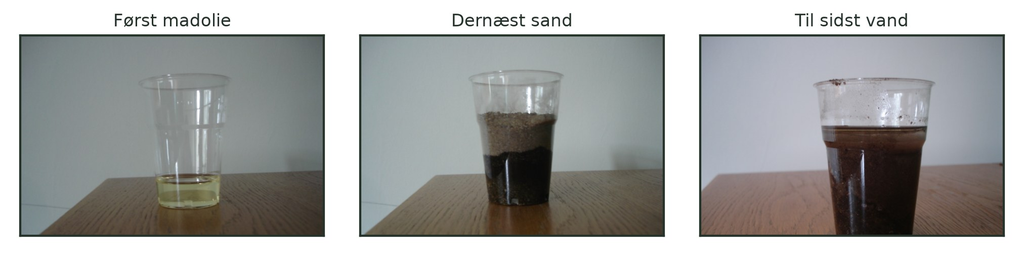

**NoteMaterialer (pr. gruppe)**

- Glas eller et gennemsigtigt plastikkrus
- Sand
- Vand
- Madolie
- Måleglas, 100 mL
- Vægt (0,1 g eller finere)

**TipTip**

Hæld vandet forsigtigt ned ad glassets inderside eller over en ske, så sandlaget ikke bliver rodet op. Rør ikke i glasset undervejs — olien skal selv finde vej op gennem sandet.

### Iagttagelser

Tabel 2: Iagttagelser undervejs i forsøget.

| Hvornår | Hvad ser I? |
| --- | --- |
| Lige efter vandet er hældt i |  |
| Efter ca. 5 minutter |  |
| Efter 20–30 minutter (eller næste dag) |  |

Tegn til sidst glasset af, som det ser ud ved forsøgets slutning, og sæt navn på lagene.

## Del 3: Oliens densitet

Forsøget i del 2 virker kun, fordi olien er lettere end vandet. Her sætter I tal på forskellen.

### Fremgangsmåde

1. Vej et tomt, tørt måleglas, og notér massen.
2. Afmål præcis 100 mL vand i måleglasset, og vej det igen.
3. Tøm og tør måleglasset — eller tag et andet, tørt måleglas af samme slags.
4. Afmål præcis 100 mL madolie, og vej på samme måde.

Tabel 3: Vejninger til bestemmelse af densiteten.

|  | Vand | Madolie |
| --- | --- | --- |
| Masse af tomt måleglas (g) |  |  |
| Masse af måleglas med 100 mL væske (g) |  |  |
| Væskens masse (g) |  |  |

## Databehandling

1. Beregn væskernes masse i Tabel 3 som forskellen mellem måleglasset med og uden væske.
2. Beregn densiteten af vand og madolie. Densiteten er massen pr. rumfang, og rumfanget er de 100 mL, altså 100 cm³:

$$\rho = \frac{m}{V}$$

Tabel 4: Beregnet densitet sammenlignet med tabelværdier ved stuetemperatur.

|  | Vand | Madolie |
| --- | --- | --- |
| Densitet (g/cm³) |  |  |
| Tabelværdi (g/cm³) | 1,00 | ca. 0,92 |
| Afvigelse fra tabelværdien (%) |  |  |

3. Beregn, hvor mange procent lettere olien er end vandet:

$$\text{Forskel (\%)} = \frac{\rho_{\text{vand}} - \rho_{\text{olie}}}{\rho_{\text{vand}}} \cdot 100$$

4. Sammenlign jeres målte densiteter med tabelværdierne i Tabel 4, og beregn afvigelsen i procent på samme måde. Hvor stor er usikkerheden ved at aflæse 100 mL i måleglasset?

## Journalspørgsmål

1. Beskriv, hvad I så i glasset i del 2. Relatér derefter forsøget til teorien om oliedannelse, migration, kildebjergarter, reservoirbjergarter og oliefælder: hvilke af de begreber har vi i vores forsøg, og hvilke har vi ikke?
2. Brug jeres densiteter fra del 3 til at forklare, hvorfor olien bevægede sig op gennem sandet — og hvorfor den blev liggende øverst.
3. Råolie fra Nordsøen har en densitet omkring 0,85 g/cm³, mens det salte porevand i undergrunden er tungere end 1,00 g/cm³. Hvad betyder den forskel for oliens vej op gennem undergrunden, og hvad skal der til for at standse den i en oliefælde?
4. Diskutér, hvilke energimæssige og miljømæssige konsekvenser det ville have haft, hvis oliens densitet havde været større end vands. Hvor ville vores Nordsøolie så befinde sig i dag, og hvad ville det betyde for vores muligheder for at bruge den?
5. Hvilke problemer er der forbundet med olie som energiråstof?
6. **Fejlkilder.** Hvad er der fx galt ved at bruge vegetabilsk olie frem for mineralsk olie, og løst sand frem for sandsten? Find selv flere forskelle mellem modellen og undergrunden.